# Las siete nuevas herramientas de control de calidad

En el control de calidad, no solo es necesario analizar datos numéricos, sino también utilizar datos ligüísticos.

- Diagrama de afinidad （親和図法）
- Diagrama de árbol （系統図法）
- Diagrama de relaciones （連関図法）
- Diagrama de matriz （マトリックス図法）

[Audio_1](https://drive.google.com/file/d/1hRgYvPDU8C_cShA1BUaczrHbhLf30lRK/view?usp=drive_link)

```python
import os

try:
  os.chdir('../Python/QCKentei2')
except:
  pass

path = os.getcwd()
```

## 02-01 Método del diagrama de afinidad

親和図法

### 1. ¿Qué es el método del diagrama de afinidad?

親和図法とは

**Diagrama de afinidad**: Es un diagrama que, frente a un problema caótico, capta hechos, opiniones e ideas en forma de datos cualitativos (lingüísticos), y los agrupa según su afinidad para clarificar el problema que debe resolverse.

El Diagrama de Afinidad se utiliza para organizar la similitud entre un gran número de hechos, ideas y otros elementos, con el fin de clarificar la estructura de un problema y la situación ideal, especialmente cuando el problema es complejo y existe confusión sobre cómo abordarlo.

Al consolidar ideas o elementos individuales similares y agruparlos bajo un punto común que los resuma o las integre mejor, es posible organizar una gran cantidad de elementos en un número menor de grupos relacionados.

### 2. Cómo utilizar el método del diagrama de afinidad

親和図法の活用方法

- Verificación de hechos: En campos desconocidos o inexplorados, se trata de capturar cada hecho individual en medio del caos para luego comprender la estructura que forman.
- Construcción de una filosofía: En un campo desconocido e inexplorado, se trata de partir de cero para organizar tus propias ideas y construir una filosofía personal
- Rompiendo el statu quo: Se trata de romper los conceptos preconcebidos basados en la experiencia convencional y de organizar nuevas formas de pensar.
- Revisión y reinvención: Se trata de tomar las filosofías y marcos teóricos desarrollados por predecesores sobre un tema, para luego organizar tu propia filosofía o marco teórico.
- Organización participativa: En este caso, el método se usa para reunir a personas de diferentes orígenes para que se entiendan mutuamente y creen un trabajo en equipo participativo.
- Extracción de problemas estructurales de la empresa en el marco de las actividades de TQM (Gestión de la Calidad Total).
- Prevención de la recurrencia de fracasos en un equipo de planificación de productos municipales.
- Establecimiento de temas clave en el lugar de trabajo para círculos de control de calidad.
- Formulación de la política operativa para un líder de círculo de control de calidad.
- Planificación de un producto nuevo y atractivo.
- Selección de temas clave en el lugar de trabajo.
- Establecimiento de los objetivos para el próximo año.

### 3. Puntos a tener en cuenta con el método del diagrama de afinidad

親和図法の留意点

1. Los datos lingüisticos se expresan con la estructura "sujeto + predicado".
2. Para crear una tarjeta de afinidad, se deben seleccionar elementos que tengan afinidad, sin pensar lógicamente.
3. No se deben crear tarjetas de afinidad mediante la simple colección de palabras claves.
4. Crear tarjetas de afinidad sin omitir el contenido de dos o tres lingüísticos, y conservando la esencia de cada uno.
5. Las tarjetas de afinidad deben seguir la regla básica de utilizar la estructura de oración "sujeto + predicado".

[Audio_2](https://drive.google.com/file/d/1ThrgkOzJu9AnMjPZsrRKAPV6Y6i0Bb4l/view?usp=drive_link)

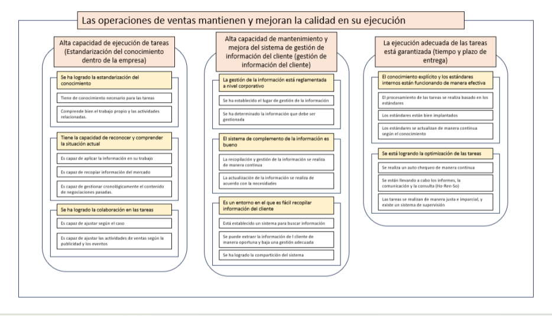

```python
from IPython.display import display
from PIL import Image

img = Image.open('Graph2/Afinidad.png')
display(img)
```

## 02-02 Método del diagrama de relaciones

連関図法

### 1. ¿Cuál es el método del diagrama de relaciones?

連関図法とは

**Diagrama de relaciones**: Es un diagrama que conecta lógicamente las relaciones de causa y efecto en situaciones donde existan causas complejas e interrelacionadas.

### 2. ¿Cómo utilizar el método del diagrama de relaciones?

連関図法の活用方法

- Organizar problemas donde los factores están interrelacionados de manera compleja.
- Examinar los problemas desde una perspectiva amplia, desde la etapa de planificación.
- Identificar con precisión los elementos prioritarios.
- Obtener el consenso de los miembros.
- Permite la expresión libre y sin restricciones, conectando eficazmente problemas y sus causas.
- Ayuda a la reestructuración y al desarrollo de ideas, sin limitarse a un marco preestablecido.
- Promoción de las actividades de Gestión de la Calidad Total (TQM).
- Despliegue de la política de la empresa.
- Medidas para combatir defectos en los procesos de fabricación.
- Promoción y despliegue de actividades de grupos pequeños.
- Medidas contra las quejas del mercado.
- Mejora de procesos.

### 3. Puntos a tener en cuenta con el método del diagrama de relaciones.

連関図法の留意点

1. Al investigar las causas, se debe enfocar el desarrollo en aquellas que son atribuibles a nuestra propia responsabilidad (causas que podemos solucionar).
2. Cuando se detecta un bucle en el diagrama de relaciones, se debe idear un medio para romper el bucle con el fin de resolver el problema.
3. Es mejor usar el diagrama de causa y efecto (Ishikawa) que el diagrama de relaciones cuando no hay relación de "causa -> efecto" entre las causas secundarias y terciarias de una causa primaria, o entre las causas secundarias y terciarias de diferentes causas primarias.
4. Las causas importantes no se deben seleccionar por votación. Si no se razona de forma teórica, se pueden cometer errores. Las causas importantes se descubren durante el proceso de creación del diagrama de relaciones, o se llega a la conclusión de "ya veo, es esto".
5. Los datos que tienen muchas flechas que entran y salen son más propensos a ser factores importantes, por lo que es mejor revisarlos con atención.

[Audio_3](https://drive.google.com/file/d/1RIPlH24dDmh5dWKnd8hSxMQyq8x0T-yG/view?usp=drive_link)

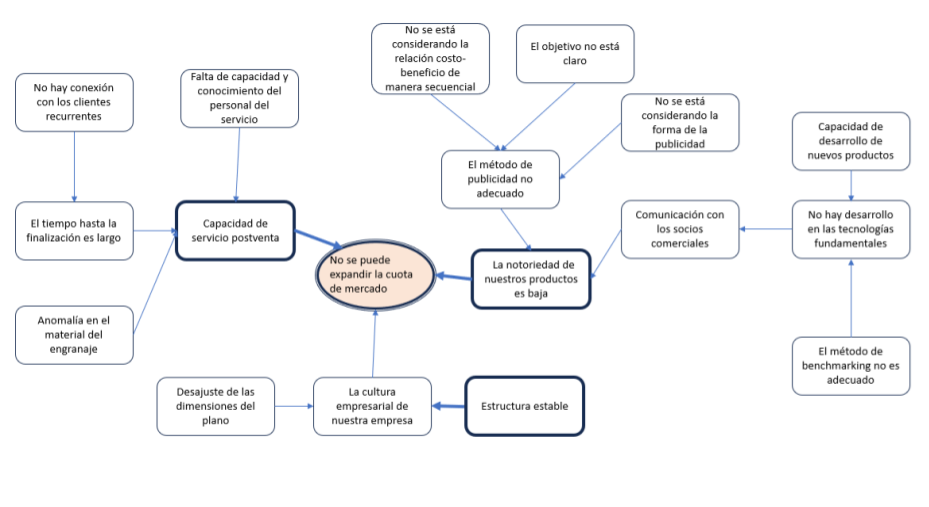

```python
img = Image.open('Graph2/Relaciones.png')
display(img)
```

## 02-03 Método del diagrama sistemático

系統図法

### 1. ¿Cuál es el método del diagrama sistemático?

系統図法とは

**Diagrama de árbol**: Es un diagrama que establece un objetivo y desarrolla sistemáticamente los medios para alcanzarlo.

### 2. Cómo utilizar el método del diagrama sistemático.

系統図の活用方法

- Selección de medidas viables para ressolver un problema o un desafio.
- Clarificación de las tareas que debe llevar a cabo cada departamento y cada responsable.
- Obtención de la satisfacción del cliente.
- Formulación de la política anual.

### 3. Puntos a tener en cuenta con el método del diagrama sistemático.

系統図の留意点

1. En un diagrama de árbol, se generan numerosas ideas como medidas finales. Sin embargo, dado que es imposible implementarlas todas, se deben seleccionar las más óptimas. Para ello, se puede utilizar un diagrama de matriz para elegir las medidas más adecuadas basándose en criterios de evaluación como la efectividad, la viabilidad y la economía.
2. Una vez que el diagrama de árbol haya alcanzado un tamaño razonable, se debe revisar de derecha a izquierda haciendo repetidamente la pregunta: ¿Se puede alcanzar el objetivo con estas medidas?. Esto sirve para verificar si hay omisiones o contradicciones en las medidas.
3. El despliegue de las medidas debe llegar hasta una etapa en la que se puedan implementar de manera concreta. Además, un despliegue en el que haya una sola medida de bajo nivel que corresponda a un objetivo no es una buena estrategia. Se debe procurar siempre desplegar al menos dos elementos por nivel.

[Audio_4](https://drive.google.com/file/d/16egz3LAT9goE79BRSGJwRPTJC3a78W6Y/view?usp=drive_link)

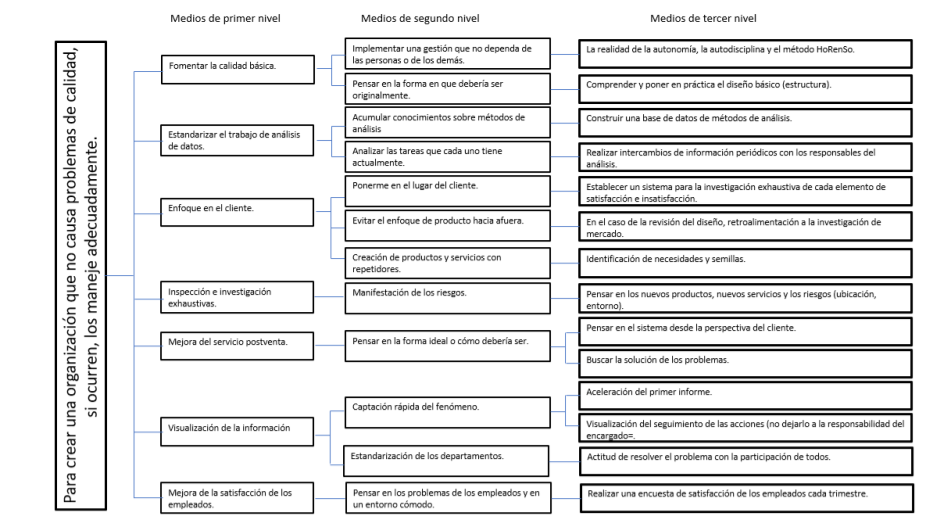

```python
img = Image.open('Graph2/Sistemático.png')
display(img)
```

## 02-04 Método del diagrama matricial

マトリックス図法

### 1. ¿Cuál es el método del diagrama matricial?

マトリックス図法とは

**El diagrama matricial**: Es un diagrama que organiza elementos en una disposición bidimensional según las filas y las columnas.

### 2. Cómo utilizar el método del diagrama matricial.

マトリックス図法の活用方法

- Encontrar puntos de vista para nuevos productos o mejoras de productos.
- Clarificar una situación compleja donde una sola característica sustituta corresponda a múltiples requisitos de calidad, resultando en líneas que se cruzan.
- Clarificar la relación entre las características de calidad que deben ser garantizadas en un producto y las funciones de gestión correspondientes, para asegurar un sistema de garantía de calidad fiable.
- Clarificar la relación entre las características de calidad garantizadas del producto, los items de prueba y medición, y el equipo de prueba y medición, para reforzar y optimizar el sistema de garantía de calidad.
- Cuando varios fenómenos de defecto tienen múltiples causas en común, el diagrama se utiliza para clarificar la relación entre estos defectos y sus causas, permitiendo erradicar múltiples problemas de una sola vez.
- Verificación de la relación entre el gráfico QA (Aseguramiento de Calidad) y el diagrama de flujo del proceso de control de calidad.
- Uso como tabla de selección de temas.

### 3. Puntos a tener en cuenta con el método del diagrama matricial

マトリックス図法の留意点

Al seleccionar la medida más adecuada, se obtiene una evaluación integral calculando la suma de los puntos de valoración (por ejemplo, 5, 3, 1) en función de la efectividad, la viabilidad y la economía, y se priorizan las medidas con las puntuaciones más altas.

A veces, se descartan medidas debidas a una baja puntuación en viabilidad o economía. Sin embargo, en lugar de rechazarlas sin más, es importante ser más creativo y reflexionar sobre cómo mejorar la viabilidad y la economía de la medida.

[Audio_5](https://drive.google.com/file/d/1Vi7E2NW4xyfWZbdBeaxU_lmBmHxBukzs/view?usp=drive_link)

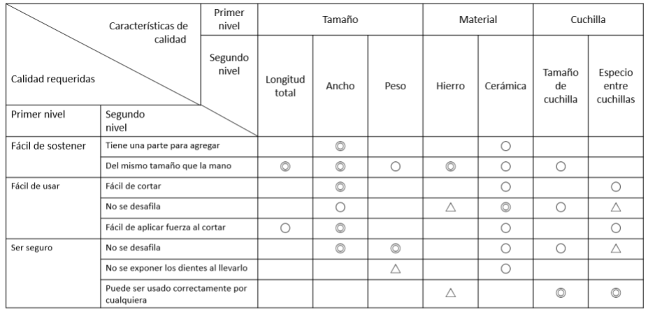

```python
img = Image.open('Graph2/Matrís.png')
display(img)
```

## Por favor, responda a las preguntas del examen de práctica a través del siguiente enlace.

[Simulacro de examen](https://forms.gle/6DVFm5WBQNkmN1EZ9)

```python
notebook_name = 'QCKentei2-2.ipynb'
notebook_name_html = notebook_name.replace(".ipynb",".html")

!jupyter nbconvert --to html {notebook_name}
```

```
[NbConvertApp] Converting notebook QCKentei2-2.ipynb to html
[NbConvertApp] Writing 1445408 bytes to QCKentei2-2.html
```